# ReneWind_Project_Predictive_System

### Problem Statement

ReneWind is a company focused on enhancing the efficiency and reliability of wind energy production. As wind energy systems involve complex machinery such as turbines, gearboxes, blades, and generators, unexpected failures in these components can lead to significant operational downtime and high maintenance costs.

To address this challenge, ReneWind aims to implement a predictive system capable of analyzing sensor-generated data from wind turbines to anticipate potential failures. By identifying which components are likely to fail, organizations can act proactively, performing repairs before catastrophic breakdowns occur. This approach not only minimizes downtime but also significantly lowers maintenance and replacement costs.

### Objective

The main goal of this project is to leverage machine learning techniques to predict generator failures in wind turbines using sensor data. Specific objectives include:

1. Developing predictive models that classify whether a generator is likely to fail (“1”) or remain operational (“0”).
2. Tuning and evaluating multiple classification algorithms to identify the model with the highest accuracy and cost-efficiency.
3. Reducing operational costs by prioritizing repair over replacement and minimizing unnecessary inspections through accurate prediction of failures.
4. Providing actionable insights for maintenance teams to schedule timely interventions and prevent costly breakdowns.

### Data Description

The dataset provided consists of transformed sensor readings from wind turbines, with confidentiality preserved by anonymization. The details are as follows:

- **Training set:** 20,000 observations with 40 predictor variables and 1 target variable.
- **Test set:** 5,000 observations with the same structure as the training set.
- **Predictors:** Include sensor measurements related to environmental conditions (e.g., temperature, humidity, wind speed) and mechanical components of turbines (e.g., gearbox, blades, tower).
- **Target variable:** Indicates generator failure, where 1 represents a failure and 0 represents normal operation.
- **Cost considerations:**
  - Repairing a failure (True Positive): Lower cost than full replacement.
  - Replacing a missed failure (False Negative): Highest cost due to unexpected breakdown.
  - Inspection of non-failing units (False Positive): Lower cost than repair.

The dataset provides a foundation for building and evaluating predictive models that balance both accuracy and operational cost efficiency in wind turbine maintenance.

```python
# Import libraries
import numpy as np
import pandas as pd
import matplotlib.pyplot as plt
import seaborn as sns

from sklearn.model_selection import train_test_split
from sklearn.preprocessing import StandardScaler
from sklearn.metrics import classification_report, confusion_matrix, roc_auc_score
from sklearn.utils.class_weight import compute_class_weight

import tensorflow as tf
from tensorflow.keras.models import Sequential
from tensorflow.keras.layers import Dense, Dropout
from tensorflow.keras.optimizers import SGD, Adam
```

```python
# Load training dataset
train=pd.read_csv("/content/Train.csv")
train.head() #showing first 5 rows
```

|  | V1 | V2 | V3 | V4 | V5 | V6 | V7 | V8 | V9 | V10 | ... | V32 | V33 | V34 | V35 | V36 | V37 | V38 | V39 | V40 | Target |
| --- | --- | --- | --- | --- | --- | --- | --- | --- | --- | --- | --- | --- | --- | --- | --- | --- | --- | --- | --- | --- | --- |
| 0 | -4.464606 | -4.679129 | 3.101546 | 0.506130 | -0.221083 | -2.032511 | -2.910870 | 0.050714 | -1.522351 | 3.761892 | ... | 3.059700 | -1.690440 | 2.846296 | 2.235198 | 6.667486 | 0.443809 | -2.369169 | 2.950578 | -3.480324 | 0 |
| 1 | 3.365912 | 3.653381 | 0.909671 | -1.367528 | 0.332016 | 2.358938 | 0.732600 | -4.332135 | 0.565695 | -0.101080 | ... | -1.795474 | 3.032780 | -2.467514 | 1.894599 | -2.297780 | -1.731048 | 5.908837 | -0.386345 | 0.616242 | 0 |
| 2 | -3.831843 | -5.824444 | 0.634031 | -2.418815 | -1.773827 | 1.016824 | -2.098941 | -3.173204 | -2.081860 | 5.392621 | ... | -0.257101 | 0.803550 | 4.086219 | 2.292138 | 5.360850 | 0.351993 | 2.940021 | 3.839160 | -4.309402 | 0 |
| 3 | 1.618098 | 1.888342 | 7.046143 | -1.147285 | 0.083080 | -1.529780 | 0.207309 | -2.493629 | 0.344926 | 2.118578 | ... | -3.584425 | -2.577474 | 1.363769 | 0.622714 | 5.550100 | -1.526796 | 0.138853 | 3.101430 | -1.277378 | 0 |
| 4 | -0.111440 | 3.872488 | -3.758361 | -2.982897 | 3.792714 | 0.544960 | 0.205433 | 4.848994 | -1.854920 | -6.220023 | ... | 8.265896 | 6.629213 | -10.068689 | 1.222987 | -3.229763 | 1.686909 | -2.163896 | -3.644622 | 6.510338 | 0 |

5 rows × 41 columns

```python
# Load testing dataset
test=pd.read_csv("/content/Test.csv")
test.head() #Show first 5 rows
```

|  | V1 | V2 | V3 | V4 | V5 | V6 | V7 | V8 | V9 | V10 | ... | V32 | V33 | V34 | V35 | V36 | V37 | V38 | V39 | V40 | Target |
| --- | --- | --- | --- | --- | --- | --- | --- | --- | --- | --- | --- | --- | --- | --- | --- | --- | --- | --- | --- | --- | --- |
| 0 | -0.613489 | -3.819640 | 2.202302 | 1.300420 | -1.184929 | -4.495964 | -1.835817 | 4.722989 | 1.206140 | -0.341909 | ... | 2.291204 | -5.411388 | 0.870073 | 0.574479 | 4.157191 | 1.428093 | -10.511342 | 0.454664 | -1.448363 | 0 |
| 1 | 0.389608 | -0.512341 | 0.527053 | -2.576776 | -1.016766 | 2.235112 | -0.441301 | -4.405744 | -0.332869 | 1.966794 | ... | -2.474936 | 2.493582 | 0.315165 | 2.059288 | 0.683859 | -0.485452 | 5.128350 | 1.720744 | -1.488235 | 0 |
| 2 | -0.874861 | -0.640632 | 4.084202 | -1.590454 | 0.525855 | -1.957592 | -0.695367 | 1.347309 | -1.732348 | 0.466500 | ... | -1.318888 | -2.997464 | 0.459664 | 0.619774 | 5.631504 | 1.323512 | -1.752154 | 1.808302 | 1.675748 | 0 |
| 3 | 0.238384 | 1.458607 | 4.014528 | 2.534478 | 1.196987 | -3.117330 | -0.924035 | 0.269493 | 1.322436 | 0.702345 | ... | 3.517918 | -3.074085 | -0.284220 | 0.954576 | 3.029331 | -1.367198 | -3.412140 | 0.906000 | -2.450889 | 0 |
| 4 | 5.828225 | 2.768260 | -1.234530 | 2.809264 | -1.641648 | -1.406698 | 0.568643 | 0.965043 | 1.918379 | -2.774855 | ... | 1.773841 | -1.501573 | -2.226702 | 4.776830 | -6.559698 | -0.805551 | -0.276007 | -3.858207 | -0.537694 | 0 |

5 rows × 41 columns

```python
# Shape of training dataset
print(train.shape )

# Column names of this dataset
train.columns
```

```
(20000, 41)
```

```
Index(['V1', 'V2', 'V3', 'V4', 'V5', 'V6', 'V7', 'V8', 'V9', 'V10', 'V11',
       'V12', 'V13', 'V14', 'V15', 'V16', 'V17', 'V18', 'V19', 'V20', 'V21',
       'V22', 'V23', 'V24', 'V25', 'V26', 'V27', 'V28', 'V29', 'V30', 'V31',
       'V32', 'V33', 'V34', 'V35', 'V36', 'V37', 'V38', 'V39', 'V40',
       'Target'],
      dtype='object')
```

X_train has 20000 rows and 41 columns

List of column names in X_train : ['V1', 'V2', 'V3', 'V4', 'V5', 'V6', 'V7', 'V8', 'V9', 'V10', 'V11', 'V12', 'V13', 'V14', 'V15', 'V16', 'V17', 'V18', 'V19', 'V20', 'V21', 'V22', 'V23', 'V24', 'V25', 'V26', 'V27', 'V28', 'V29', 'V30', 'V31', 'V32', 'V33', 'V34', 'V35', 'V36', 'V37', 'V38', 'V39', 'V40', 'Target']

```python
# Shape of testing dataset
print(test.shape )

# Column names of this dataset
test.columns
```

```
(5000, 41)
```

```
Index(['V1', 'V2', 'V3', 'V4', 'V5', 'V6', 'V7', 'V8', 'V9', 'V10', 'V11',
       'V12', 'V13', 'V14', 'V15', 'V16', 'V17', 'V18', 'V19', 'V20', 'V21',
       'V22', 'V23', 'V24', 'V25', 'V26', 'V27', 'V28', 'V29', 'V30', 'V31',
       'V32', 'V33', 'V34', 'V35', 'V36', 'V37', 'V38', 'V39', 'V40',
       'Target'],
      dtype='object')
```

X_test has 5000 rows and 41 columns

List of column names in X_test: ['V1', 'V2', 'V3', 'V4', 'V5', 'V6', 'V7', 'V8', 'V9', 'V10', 'V11', 'V12', 'V13', 'V14', 'V15', 'V16', 'V17', 'V18', 'V19', 'V20', 'V21', 'V22', 'V23', 'V24', 'V25', 'V26', 'V27', 'V28', 'V29', 'V30', 'V31', 'V32', 'V33', 'V34', 'V35', 'V36', 'V37', 'V38', 'V39', 'V40', 'Target']

```python
# Summary of training dataset
train.info()
```

```
<class 'pandas.core.frame.DataFrame'>
RangeIndex: 20000 entries, 0 to 19999
Data columns (total 41 columns):
 #   Column  Non-Null Count  Dtype
---  ------  --------------  -----
 0   V1      19982 non-null  float64
 1   V2      19982 non-null  float64
 2   V3      20000 non-null  float64
 3   V4      20000 non-null  float64
 4   V5      20000 non-null  float64
 5   V6      20000 non-null  float64
 6   V7      20000 non-null  float64
 7   V8      20000 non-null  float64
 8   V9      20000 non-null  float64
 9   V10     20000 non-null  float64
```

[output cut: 33 more lines]

**Observations**

- Dataset contains 20,000 rows and 41 columns (40 features + 1 target)
- All features (V1–V40) are numerical (float type)
- Target variable is binary (int type: 0 = No Failure, 1 = Failure)
- Only V1 and V2 have missing values (18 each)
- Remaining 38 features have no missing values
- Dataset is clean and well-structured
- Memory usage is efficient (~6.3 MB)

```python
#Sum of missing values in each column of training dataset
train.isnull().sum()
```

|  | 0 |
| --- | --- |
| V1 | 18 |
| V2 | 18 |
| V3 | 0 |
| V4 | 0 |
| V5 | 0 |
| V6 | 0 |
| V7 | 0 |
| V8 | 0 |
| V9 | 0 |
| V10 | 0 |
| V11 | 0 |
| V12 | 0 |
| V13 | 0 |
| V14 | 0 |
| V15 | 0 |
| V16 | 0 |
| V17 | 0 |
| V18 | 0 |
| V19 | 0 |
| V20 | 0 |
| V21 | 0 |
| V22 | 0 |
| V23 | 0 |
| V24 | 0 |
| V25 | 0 |
| V26 | 0 |
| V27 | 0 |
| V28 | 0 |
| V29 | 0 |
| V30 | 0 |
| V31 | 0 |
| V32 | 0 |
| V33 | 0 |
| V34 | 0 |
| V35 | 0 |
| V36 | 0 |
| V37 | 0 |
| V38 | 0 |
| V39 | 0 |
| V40 | 0 |
| Target | 0 |

**dtype:** int64

V1 and V2 have total 18 misssing values each.

```python
#Sum of missing values in each column of training dataset
train.isnull().sum()
```

|  | 0 |
| --- | --- |
| V1 | 18 |
| V2 | 18 |
| V3 | 0 |
| V4 | 0 |
| V5 | 0 |
| V6 | 0 |
| V7 | 0 |
| V8 | 0 |
| V9 | 0 |
| V10 | 0 |
| V11 | 0 |
| V12 | 0 |
| V13 | 0 |
| V14 | 0 |
| V15 | 0 |
| V16 | 0 |
| V17 | 0 |
| V18 | 0 |
| V19 | 0 |
| V20 | 0 |
| V21 | 0 |
| V22 | 0 |
| V23 | 0 |
| V24 | 0 |
| V25 | 0 |
| V26 | 0 |
| V27 | 0 |
| V28 | 0 |
| V29 | 0 |
| V30 | 0 |
| V31 | 0 |
| V32 | 0 |
| V33 | 0 |
| V34 | 0 |
| V35 | 0 |
| V36 | 0 |
| V37 | 0 |
| V38 | 0 |
| V39 | 0 |
| V40 | 0 |
| Target | 0 |

**dtype:** int64

```python
#Sum of missing values in each column of testing dataset
test.isnull().sum()
```

|  | 0 |
| --- | --- |
| V1 | 5 |
| V2 | 6 |
| V3 | 0 |
| V4 | 0 |
| V5 | 0 |
| V6 | 0 |
| V7 | 0 |
| V8 | 0 |
| V9 | 0 |
| V10 | 0 |
| V11 | 0 |
| V12 | 0 |
| V13 | 0 |
| V14 | 0 |
| V15 | 0 |
| V16 | 0 |
| V17 | 0 |
| V18 | 0 |
| V19 | 0 |
| V20 | 0 |
| V21 | 0 |
| V22 | 0 |
| V23 | 0 |
| V24 | 0 |
| V25 | 0 |
| V26 | 0 |
| V27 | 0 |
| V28 | 0 |
| V29 | 0 |
| V30 | 0 |
| V31 | 0 |
| V32 | 0 |
| V33 | 0 |
| V34 | 0 |
| V35 | 0 |
| V36 | 0 |
| V37 | 0 |
| V38 | 0 |
| V39 | 0 |
| V40 | 0 |
| Target | 0 |

**dtype:** int64

V1 has 5 missing values and V2 has 6 missing values.

```python
# Statistical summary of training dataset
train.describe()
```

|  | V1 | V2 | V3 | V4 | V5 | V6 | V7 | V8 | V9 | V10 | ... | V32 | V33 | V34 | V35 | V36 | V37 | V38 | V39 | V40 | Target |
| --- | --- | --- | --- | --- | --- | --- | --- | --- | --- | --- | --- | --- | --- | --- | --- | --- | --- | --- | --- | --- | --- |
| count | 19982.000000 | 19982.000000 | 20000.000000 | 20000.000000 | 20000.000000 | 20000.000000 | 20000.000000 | 20000.000000 | 20000.000000 | 20000.000000 | ... | 20000.000000 | 20000.000000 | 20000.000000 | 20000.000000 | 20000.000000 | 20000.000000 | 20000.000000 | 20000.000000 | 20000.000000 | 20000.000000 |
| mean | -0.271996 | 0.440430 | 2.484699 | -0.083152 | -0.053752 | -0.995443 | -0.879325 | -0.548195 | -0.016808 | -0.012998 | ... | 0.303799 | 0.049825 | -0.462702 | 2.229620 | 1.514809 | 0.011316 | -0.344025 | 0.890653 | -0.875630 | 0.055500 |
| std | 3.441625 | 3.150784 | 3.388963 | 3.431595 | 2.104801 | 2.040970 | 1.761626 | 3.295756 | 2.160568 | 2.193201 | ... | 5.500400 | 3.575285 | 3.183841 | 2.937102 | 3.800860 | 1.788165 | 3.948147 | 1.753054 | 3.012155 | 0.228959 |
| min | -11.876451 | -12.319951 | -10.708139 | -15.082052 | -8.603361 | -10.227147 | -7.949681 | -15.657561 | -8.596313 | -9.853957 | ... | -19.876502 | -16.898353 | -17.985094 | -15.349803 | -14.833178 | -5.478350 | -17.375002 | -6.438880 | -11.023935 | 0.000000 |
| 25% | -2.737146 | -1.640674 | 0.206860 | -2.347660 | -1.535607 | -2.347238 | -2.030926 | -2.642665 | -1.494973 | -1.411212 | ... | -3.420469 | -2.242857 | -2.136984 | 0.336191 | -0.943809 | -1.255819 | -2.987638 | -0.272250 | -2.940193 | 0.000000 |
| 50% | -0.747917 | 0.471536 | 2.255786 | -0.135241 | -0.101952 | -1.000515 | -0.917179 | -0.389085 | -0.067597 | 0.100973 | ... | 0.052073 | -0.066249 | -0.255008 | 2.098633 | 1.566526 | -0.128435 | -0.316849 | 0.919261 | -0.920806 | 0.000000 |
| 75% | 1.840112 | 2.543967 | 4.566165 | 2.130615 | 1.340480 | 0.380330 | 0.223695 | 1.722965 | 1.409203 | 1.477045 | ... | 3.761722 | 2.255134 | 1.436935 | 4.064358 | 3.983939 | 1.175533 | 2.279399 | 2.057540 | 1.119897 | 0.000000 |
| max | 15.493002 | 13.089269 | 17.090919 | 13.236381 | 8.133797 | 6.975847 | 8.006091 | 11.679495 | 8.137580 | 8.108472 | ... | 23.633187 | 16.692486 | 14.358213 | 15.291065 | 19.329576 | 7.467006 | 15.289923 | 7.759877 | 10.654265 | 1.000000 |

8 rows × 41 columns

**Observations**

- Most features have mean close to 0, indicating data is likely standardized/normalized
- Features contain both positive and negative values, showing symmetric distribution
- Standard deviation varies across features, indicating different levels of variability
- Presence of extreme min and max values shows possible outliers in data
- Difference between mean and median (50%) in some features shows light skewness
- Features like V32, V36 show high spread (high std) indicates more variability
- Target variable mean = 0.0555 indicates only ~5.5% failures

```python
train['Target'].value_counts(normalize=True)
```

| Target | proportion |
| --- | --- |
| 0 | 0.9445 |
| 1 | 0.0555 |

**dtype:** float64

**Observations**

- Class 0 (No Failure) = 94.45%
- Class 1 (Failure) = 5.55%
- Dataset is highly imbalanced

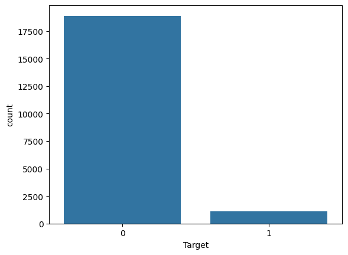

```python
#Univariate Analysis
#1. Target Variable
sns.countplot(x='Target', data=train)
plt.show()
```

Dataset is highly imbalanced because count of 0 is very high in comparison to 1

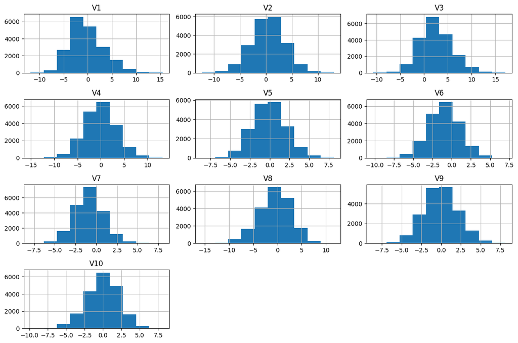

```python
#2. Feature Distribution
train.iloc[:, :10].hist(figsize=(12,8))
plt.tight_layout()
plt.show()
```

Observations:

- Most features are centered around 0
- Distributions look approximately normal (bell-shaped)
- Some features show wide spread means high variance
- Few features show extreme values means possible outliers

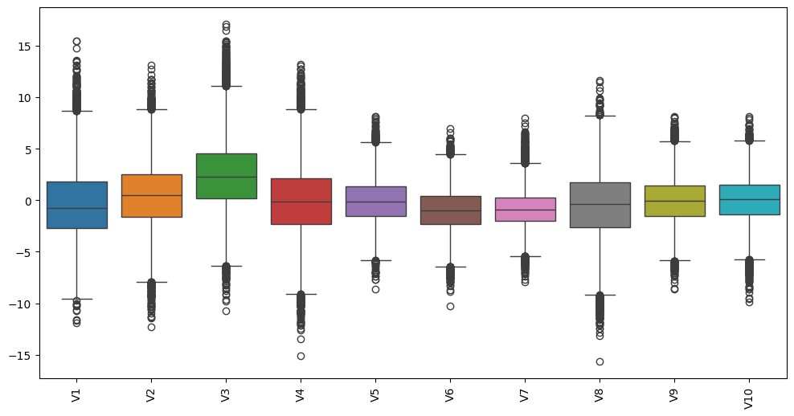

```python
#3. Boxplot (Outliers Detection)
plt.figure(figsize=(12,6))
sns.boxplot(data=train.iloc[:, :10])
plt.xticks(rotation=90)
plt.show()
```

**Observations:**

- Many features contain outliers
- Outliers are expected in sensor data
- No need to remove aggressively

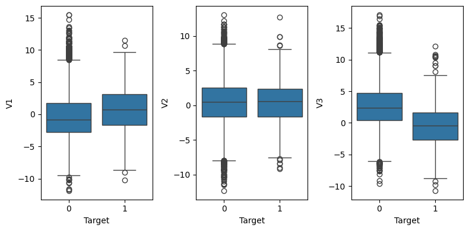

```python
#Bivariate Analysis
#1. Feature vs Target (Boxplot)
plt.figure(figsize=(8,4))  # one single figure

plt.subplot(1,3,1)
sns.boxplot(x='Target', y='V1', data=train)

plt.subplot(1,3,2)
sns.boxplot(x='Target', y='V2', data=train)

plt.subplot(1,3,3)
sns.boxplot(x='Target', y='V3', data=train)

plt.tight_layout()
plt.show()
```

**Observations:**

V1 shows a positive relationship with failure, V3 shows a clear negative relationship, while V2 has overlapping distributions indicating weaker predictive power. Overall, V1 and V3 are strong predictors, and the presence of outliers is consistent with sensor data.

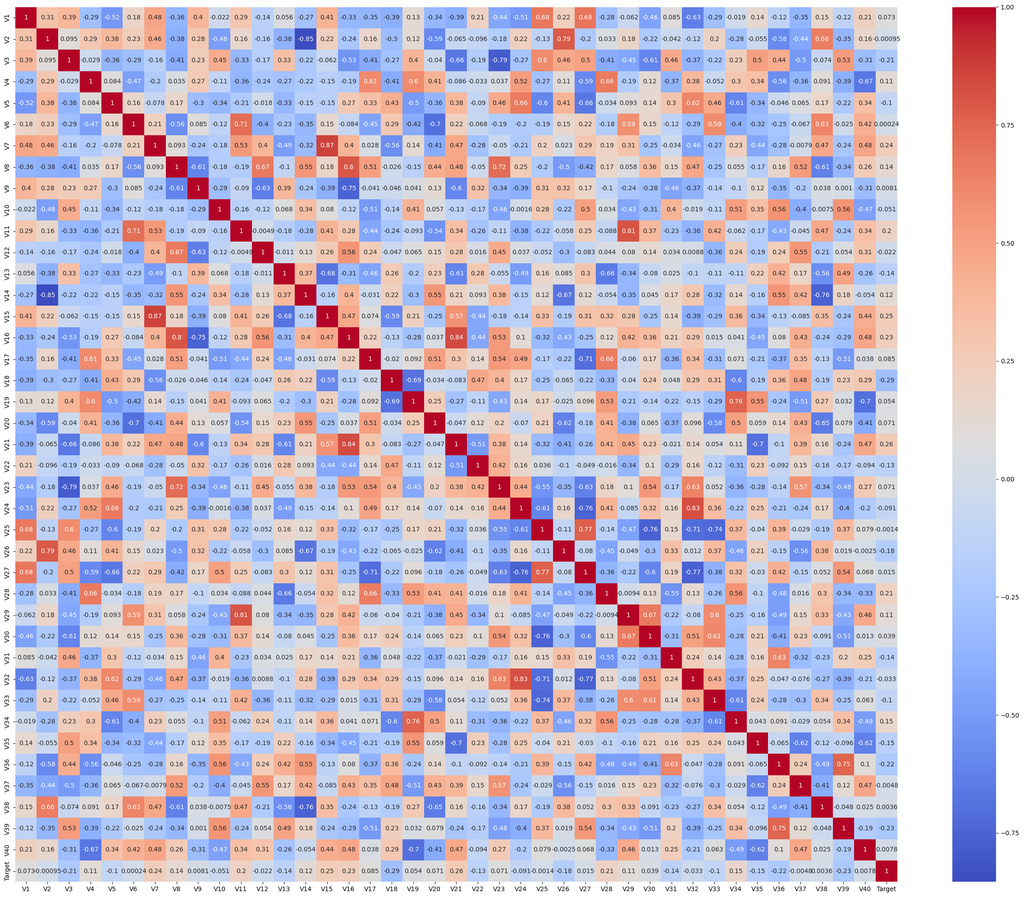

```python
#2. Correlation Analysis
plt.figure(figsize=(25,20))
sns.heatmap(train.corr(), annot=True, cmap='coolwarm')
plt.tight_layout()
plt.show()
```

```python
#Data Preprocessing
#Total Missing Values() in training dataset)
print('Train dataset Total Missing Values:', train.isnull().sum().sum())

#Total Missing Values() in testing dataset
print('Test Dataset Total Missing values:',test.isnull().sum().sum())
```

```
Train dataset Total Missing Values: 36
Test Dataset Total Missing values: 11
```

Both datasets contain missing values

```python
# If missing values exist
train.fillna(train.mean(), inplace=True)
test.fillna(test.mean(), inplace=True)
```

```python
#Checking missing values again for both the dataset
print(train.isnull().sum().sum())

print(test.isnull().sum().sum())
```

```
0
0
```

After handling missing values, no missing values remain in the dataset.

```python
# Split Data (No Data Leakage)
X = train.drop('Target', axis=1)
y = train['Target']

X_train, X_val, y_train, y_val = train_test_split(
    X, y, test_size=0.2, stratify=y, random_state=42
)
```

The data is divided into training and validation sets in an 80:20 ratio using stratified sampling to maintain class distribution.

```python
# Handling Test Data
X_test=test.drop('Target', axis=1)
Y_test=test['Target']
```

Now testing data has same number of features as training data

```python
# Scaling
scaler = StandardScaler()

X_train = scaler.fit_transform(X_train)
X_val = scaler.transform(X_val)
test_scaled = scaler.transform(X_test)
```

**Metric Selection**

Chosen Metric: Recall + F1-score + ROC-AUC

Reason is as follows:

1. False Negatives (FN) are very costly refers to missed failures leading to expensive replacement.
2. So, we prioritize Recall (catch failures)
3. Use F1-score for balance
4. ROC-AUC for overall performance

```python
#Base Neural Network (SGD)
#Model 1

model_1 = Sequential([
    Dense(64, activation='relu', input_shape=(X_train.shape[1],)),
    Dense(32, activation='relu'),
    Dense(1, activation='sigmoid')
])

model_1.compile(
    optimizer=SGD(learning_rate=0.01),
    loss='binary_crossentropy',
    metrics=['Recall']
)

history_1 = model_1.fit(
    X_train, y_train,
    validation_data=(X_val, y_val),
    epochs=20,
    batch_size=32,
    verbose=1
)
```

```
500/500 ━━━━━━━━━━━━━━━━━━━━ 2s 2ms/step - Recall: 0.0597 - loss: 0.2084 - val_Recall: 0.2252 - val_loss: 0.1615
500/500 ━━━━━━━━━━━━━━━━━━━━ 1s 2ms/step - Recall: 0.3412 - loss: 0.1377 - val_Recall: 0.4144 - val_loss: 0.1278
500/500 ━━━━━━━━━━━━━━━━━━━━ 1s 2ms/step - Recall: 0.4944 - loss: 0.1151 - val_Recall: 0.5405 - val_loss: 0.1099
500/500 ━━━━━━━━━━━━━━━━━━━━ 1s 3ms/step - Recall: 0.5743 - loss: 0.1018 - val_Recall: 0.6126 - val_loss: 0.0980
500/500 ━━━━━━━━━━━━━━━━━━━━ 2s 3ms/step - Recall: 0.6137 - loss: 0.0921 - val_Recall: 0.6712 - val_loss: 0.0894
500/500 ━━━━━━━━━━━━━━━━━━━━ 2s 2ms/step - Recall: 0.6655 - loss: 0.0845 - val_Recall: 0.6712 - val_loss: 0.0823
500/500 ━━━━━━━━━━━━━━━━━━━━ 1s 2ms/step - Recall: 0.6982 - loss: 0.0784 - val_Recall: 0.7162 - val_loss: 0.0767
500/500 ━━━━━━━━━━━━━━━━━━━━ 1s 2ms/step - Recall: 0.7230 - loss: 0.0734 - val_Recall: 0.7568 - val_loss: 0.0725
500/500 ━━━━━━━━━━━━━━━━━━━━ 1s 2ms/step - Recall: 0.7421 - loss: 0.0695 - val_Recall: 0.7523 - val_loss: 0.0688
500/500 ━━━━━━━━━━━━━━━━━━━━ 1s 2ms/step - Recall: 0.7613 - loss: 0.0662 - val_Recall: 0.7748 - val_loss: 0.0662
500/500 ━━━━━━━━━━━━━━━━━━━━ 1s 2ms/step - Recall: 0.7691 - loss: 0.0636 - val_Recall: 0.7793 - val_loss: 0.0636
500/500 ━━━━━━━━━━━━━━━━━━━━ 1s 2ms/step - Recall: 0.7770 - loss: 0.0615 - val_Recall: 0.8198 - val_loss: 0.0626
500/500 ━━━━━━━━━━━━━━━━━━━━ 1s 2ms/step - Recall: 0.7782 - loss: 0.0597 - val_Recall: 0.8198 - val_loss: 0.0601
500/500 ━━━━━━━━━━━━━━━━━━━━ 1s 2ms/step - Recall: 0.7872 - loss: 0.0582 - val_Recall: 0.8243 - val_loss: 0.0591
500/500 ━━━━━━━━━━━━━━━━━━━━ 1s 3ms/step - Recall: 0.7939 - loss: 0.0570 - val_Recall: 0.8378 - val_loss: 0.0579
500/500 ━━━━━━━━━━━━━━━━━━━━ 2s 3ms/step - Recall: 0.8041 - loss: 0.0558 - val_Recall: 0.8333 - val_loss: 0.0569
500/500 ━━━━━━━━━━━━━━━━━━━━ 1s 2ms/step - Recall: 0.8131 - loss: 0.0547 - val_Recall: 0.8288 - val_loss: 0.0555
500/500 ━━━━━━━━━━━━━━━━━━━━ 1s 2ms/step - Recall: 0.8086 - loss: 0.0539 - val_Recall: 0.8559 - val_loss: 0.0554
500/500 ━━━━━━━━━━━━━━━━━━━━ 1s 2ms/step - Recall: 0.8187 - loss: 0.0530 - val_Recall: 0.8423 - val_loss: 0.0542
500/500 ━━━━━━━━━━━━━━━━━━━━ 1s 2ms/step - Recall: 0.8198 - loss: 0.0523 - val_Recall: 0.8514 - val_loss: 0.0536
```

**Model 1 (SGD)**

```python
y_pred = (model_1.predict(X_val) > 0.5).astype(int)

print(classification_report(y_val, y_pred))
print("ROC-AUC:", roc_auc_score(y_val, y_pred))
```

```
125/125 ━━━━━━━━━━━━━━━━━━━━ 0s 1ms/step
              precision    recall  f1-score   support

           0       0.99      1.00      1.00      3778
           1       0.99      0.85      0.92       222

    accuracy                           0.99      4000
   macro avg       0.99      0.93      0.96      4000
weighted avg       0.99      0.99      0.99      4000

ROC-AUC: 0.9254109853633412
```

```python
#Model Improvements
#Model 2: More Layers added

model_2 = Sequential([
    Dense(128, activation='relu'),
    Dense(64, activation='relu'),
    Dense(32, activation='relu'),
    Dense(1, activation='sigmoid')
])

model_2.compile(optimizer=SGD(0.01), loss='binary_crossentropy', metrics=['Recall'])
model_2.fit(X_train, y_train, validation_data=(X_val, y_val), epochs=20)
```

```
500/500 ━━━━━━━━━━━━━━━━━━━━ 2s 2ms/step - Recall: 0.0000e+00 - loss: 0.2166 - val_Recall: 0.0045 - val_loss: 0.1603
500/500 ━━━━━━━━━━━━━━━━━━━━ 1s 2ms/step - Recall: 0.2568 - loss: 0.1344 - val_Recall: 0.4820 - val_loss: 0.1184
500/500 ━━━━━━━━━━━━━━━━━━━━ 1s 2ms/step - Recall: 0.5360 - loss: 0.1062 - val_Recall: 0.5946 - val_loss: 0.0974
500/500 ━━━━━━━━━━━━━━━━━━━━ 1s 2ms/step - Recall: 0.6306 - loss: 0.0899 - val_Recall: 0.6712 - val_loss: 0.0837
500/500 ━━━━━━━━━━━━━━━━━━━━ 2s 3ms/step - Recall: 0.6836 - loss: 0.0787 - val_Recall: 0.7342 - val_loss: 0.0742
500/500 ━━━━━━━━━━━━━━━━━━━━ 2s 2ms/step - Recall: 0.7376 - loss: 0.0709 - val_Recall: 0.7432 - val_loss: 0.0677
500/500 ━━━━━━━━━━━━━━━━━━━━ 1s 2ms/step - Recall: 0.7579 - loss: 0.0653 - val_Recall: 0.8018 - val_loss: 0.0633
500/500 ━━━━━━━━━━━━━━━━━━━━ 1s 2ms/step - Recall: 0.7883 - loss: 0.0614 - val_Recall: 0.7838 - val_loss: 0.0600
500/500 ━━━━━━━━━━━━━━━━━━━━ 1s 2ms/step - Recall: 0.7939 - loss: 0.0584 - val_Recall: 0.7973 - val_loss: 0.0572
500/500 ━━━━━━━━━━━━━━━━━━━━ 1s 2ms/step - Recall: 0.8086 - loss: 0.0558 - val_Recall: 0.8153 - val_loss: 0.0545
500/500 ━━━━━━━━━━━━━━━━━━━━ 1s 2ms/step - Recall: 0.8119 - loss: 0.0538 - val_Recall: 0.8739 - val_loss: 0.0540
500/500 ━━━━━━━━━━━━━━━━━━━━ 1s 2ms/step - Recall: 0.8232 - loss: 0.0520 - val_Recall: 0.8649 - val_loss: 0.0518
500/500 ━━━━━━━━━━━━━━━━━━━━ 1s 2ms/step - Recall: 0.8288 - loss: 0.0507 - val_Recall: 0.8649 - val_loss: 0.0504
500/500 ━━━━━━━━━━━━━━━━━━━━ 1s 2ms/step - Recall: 0.8345 - loss: 0.0494 - val_Recall: 0.8468 - val_loss: 0.0494
500/500 ━━━━━━━━━━━━━━━━━━━━ 2s 3ms/step - Recall: 0.8356 - loss: 0.0483 - val_Recall: 0.8649 - val_loss: 0.0485
500/500 ━━━━━━━━━━━━━━━━━━━━ 2s 3ms/step - Recall: 0.8491 - loss: 0.0475 - val_Recall: 0.8739 - val_loss: 0.0474
500/500 ━━━━━━━━━━━━━━━━━━━━ 1s 2ms/step - Recall: 0.8491 - loss: 0.0466 - val_Recall: 0.8604 - val_loss: 0.0467
500/500 ━━━━━━━━━━━━━━━━━━━━ 1s 2ms/step - Recall: 0.8457 - loss: 0.0458 - val_Recall: 0.8829 - val_loss: 0.0463
500/500 ━━━━━━━━━━━━━━━━━━━━ 1s 2ms/step - Recall: 0.8480 - loss: 0.0451 - val_Recall: 0.8559 - val_loss: 0.0458
500/500 ━━━━━━━━━━━━━━━━━━━━ 1s 2ms/step - Recall: 0.8547 - loss: 0.0441 - val_Recall: 0.8874 - val_loss: 0.0478
```

```
<keras.src.callbacks.history.History at 0x7c99bb3ea3f0>
```

**Model 2 (Deep Network)**

- Improved performance with better F1-score and recall
- Learns more complex patterns
- Better than Model 1

```python
# Model 3: Adam Optimizer
model_3 = Sequential([
    Dense(64, activation='relu'),
    Dense(32, activation='relu'),
    Dense(1, activation='sigmoid')
])

model_3.compile(optimizer=Adam(0.001), loss='binary_crossentropy', metrics=['Recall'])
model_3.fit(X_train, y_train, validation_data=(X_val, y_val), epochs=20)
```

```
500/500 ━━━━━━━━━━━━━━━━━━━━ 3s 4ms/step - Recall: 0.5405 - loss: 0.1198 - val_Recall: 0.7072 - val_loss: 0.0745
500/500 ━━━━━━━━━━━━━━━━━━━━ 2s 2ms/step - Recall: 0.7770 - loss: 0.0640 - val_Recall: 0.8694 - val_loss: 0.0602
500/500 ━━━━━━━━━━━━━━━━━━━━ 1s 3ms/step - Recall: 0.8243 - loss: 0.0543 - val_Recall: 0.8739 - val_loss: 0.0504
500/500 ━━━━━━━━━━━━━━━━━━━━ 2s 3ms/step - Recall: 0.8423 - loss: 0.0480 - val_Recall: 0.8559 - val_loss: 0.0528
500/500 ━━━━━━━━━━━━━━━━━━━━ 2s 2ms/step - Recall: 0.8581 - loss: 0.0444 - val_Recall: 0.8739 - val_loss: 0.0467
500/500 ━━━━━━━━━━━━━━━━━━━━ 1s 2ms/step - Recall: 0.8694 - loss: 0.0428 - val_Recall: 0.9054 - val_loss: 0.0438
500/500 ━━━━━━━━━━━━━━━━━━━━ 1s 2ms/step - Recall: 0.8784 - loss: 0.0406 - val_Recall: 0.8919 - val_loss: 0.0429
500/500 ━━━━━━━━━━━━━━━━━━━━ 1s 2ms/step - Recall: 0.8761 - loss: 0.0395 - val_Recall: 0.9099 - val_loss: 0.0420
500/500 ━━━━━━━━━━━━━━━━━━━━ 1s 2ms/step - Recall: 0.8863 - loss: 0.0374 - val_Recall: 0.9009 - val_loss: 0.0400
500/500 ━━━━━━━━━━━━━━━━━━━━ 1s 2ms/step - Recall: 0.8863 - loss: 0.0366 - val_Recall: 0.9099 - val_loss: 0.0449
500/500 ━━━━━━━━━━━━━━━━━━━━ 1s 2ms/step - Recall: 0.8908 - loss: 0.0363 - val_Recall: 0.9099 - val_loss: 0.0463
500/500 ━━━━━━━━━━━━━━━━━━━━ 2s 4ms/step - Recall: 0.8953 - loss: 0.0355 - val_Recall: 0.8829 - val_loss: 0.0412
500/500 ━━━━━━━━━━━━━━━━━━━━ 4s 7ms/step - Recall: 0.8953 - loss: 0.0350 - val_Recall: 0.9009 - val_loss: 0.0436
500/500 ━━━━━━━━━━━━━━━━━━━━ 4s 5ms/step - Recall: 0.8908 - loss: 0.0348 - val_Recall: 0.9144 - val_loss: 0.0467
500/500 ━━━━━━━━━━━━━━━━━━━━ 3s 6ms/step - Recall: 0.8953 - loss: 0.0336 - val_Recall: 0.9009 - val_loss: 0.0386
500/500 ━━━━━━━━━━━━━━━━━━━━ 7s 9ms/step - Recall: 0.8998 - loss: 0.0322 - val_Recall: 0.9099 - val_loss: 0.0422
500/500 ━━━━━━━━━━━━━━━━━━━━ 1s 2ms/step - Recall: 0.8986 - loss: 0.0320 - val_Recall: 0.9054 - val_loss: 0.0413
500/500 ━━━━━━━━━━━━━━━━━━━━ 1s 2ms/step - Recall: 0.8998 - loss: 0.0316 - val_Recall: 0.9009 - val_loss: 0.0413
500/500 ━━━━━━━━━━━━━━━━━━━━ 1s 2ms/step - Recall: 0.8953 - loss: 0.0313 - val_Recall: 0.8694 - val_loss: 0.0441
500/500 ━━━━━━━━━━━━━━━━━━━━ 1s 2ms/step - Recall: 0.8975 - loss: 0.0313 - val_Recall: 0.9099 - val_loss: 0.0454
```

```
<keras.src.callbacks.history.History at 0x7c99c93e3770>
```

**Model 3 (Adam Optimizer)**

```python
#Model 4: Dropout
model_4 = Sequential([
    Dense(64, activation='relu'),
    Dropout(0.3),
    Dense(32, activation='relu'),
    Dropout(0.3),
    Dense(1, activation='sigmoid')
])

model_4.compile(optimizer=Adam(0.001), loss='binary_crossentropy', metrics=['Recall'])
model_4.fit(X_train, y_train, validation_data=(X_val, y_val), epochs=20)
```

```
500/500 ━━━━━━━━━━━━━━━━━━━━ 3s 3ms/step - Recall: 0.3604 - loss: 0.1710 - val_Recall: 0.6261 - val_loss: 0.0911
500/500 ━━━━━━━━━━━━━━━━━━━━ 3s 4ms/step - Recall: 0.6644 - loss: 0.0949 - val_Recall: 0.7432 - val_loss: 0.0692
500/500 ━━━━━━━━━━━━━━━━━━━━ 2s 2ms/step - Recall: 0.7128 - loss: 0.0835 - val_Recall: 0.8018 - val_loss: 0.0614
500/500 ━━━━━━━━━━━━━━━━━━━━ 1s 2ms/step - Recall: 0.7477 - loss: 0.0723 - val_Recall: 0.8018 - val_loss: 0.0584
500/500 ━━━━━━━━━━━━━━━━━━━━ 1s 2ms/step - Recall: 0.7793 - loss: 0.0665 - val_Recall: 0.8514 - val_loss: 0.0516
500/500 ━━━━━━━━━━━━━━━━━━━━ 2s 3ms/step - Recall: 0.7827 - loss: 0.0629 - val_Recall: 0.8919 - val_loss: 0.0474
500/500 ━━━━━━━━━━━━━━━━━━━━ 2s 2ms/step - Recall: 0.8097 - loss: 0.0592 - val_Recall: 0.9009 - val_loss: 0.0448
500/500 ━━━━━━━━━━━━━━━━━━━━ 1s 2ms/step - Recall: 0.8232 - loss: 0.0585 - val_Recall: 0.8919 - val_loss: 0.0424
500/500 ━━━━━━━━━━━━━━━━━━━━ 1s 2ms/step - Recall: 0.8243 - loss: 0.0551 - val_Recall: 0.8694 - val_loss: 0.0419
500/500 ━━━━━━━━━━━━━━━━━━━━ 2s 3ms/step - Recall: 0.8209 - loss: 0.0536 - val_Recall: 0.9054 - val_loss: 0.0408
500/500 ━━━━━━━━━━━━━━━━━━━━ 2s 3ms/step - Recall: 0.8390 - loss: 0.0520 - val_Recall: 0.9009 - val_loss: 0.0406
500/500 ━━━━━━━━━━━━━━━━━━━━ 1s 2ms/step - Recall: 0.8457 - loss: 0.0511 - val_Recall: 0.9054 - val_loss: 0.0393
500/500 ━━━━━━━━━━━━━━━━━━━━ 1s 2ms/step - Recall: 0.8480 - loss: 0.0501 - val_Recall: 0.9009 - val_loss: 0.0404
500/500 ━━━━━━━━━━━━━━━━━━━━ 1s 2ms/step - Recall: 0.8491 - loss: 0.0508 - val_Recall: 0.8919 - val_loss: 0.0408
500/500 ━━━━━━━━━━━━━━━━━━━━ 1s 2ms/step - Recall: 0.8311 - loss: 0.0524 - val_Recall: 0.9099 - val_loss: 0.0406
500/500 ━━━━━━━━━━━━━━━━━━━━ 1s 2ms/step - Recall: 0.8457 - loss: 0.0501 - val_Recall: 0.8874 - val_loss: 0.0384
500/500 ━━━━━━━━━━━━━━━━━━━━ 1s 2ms/step - Recall: 0.8491 - loss: 0.0460 - val_Recall: 0.9009 - val_loss: 0.0392
500/500 ━━━━━━━━━━━━━━━━━━━━ 1s 2ms/step - Recall: 0.8491 - loss: 0.0488 - val_Recall: 0.9054 - val_loss: 0.0387
500/500 ━━━━━━━━━━━━━━━━━━━━ 1s 2ms/step - Recall: 0.8615 - loss: 0.0464 - val_Recall: 0.9009 - val_loss: 0.0379
500/500 ━━━━━━━━━━━━━━━━━━━━ 2s 3ms/step - Recall: 0.8446 - loss: 0.0511 - val_Recall: 0.9054 - val_loss: 0.0388
```

```
<keras.src.callbacks.history.History at 0x7c99b80a5b20>
```

**Model 4 (Dropout)**

- Highest accuracy (0.9940) and strong F1-score
- Reduced overfitting
- Very strong model

```python
#Model 5: Class Weights
weights = compute_class_weight(
    class_weight='balanced',
    classes=np.unique(y_train),
    y=y_train
)

class_weights = {0: weights[0], 1: weights[1]}

model_5 = Sequential([
    Dense(64, activation='relu'),
    Dense(32, activation='relu'),
    Dense(1, activation='sigmoid')
])

model_5.compile(optimizer=Adam(0.001), loss='binary_crossentropy', metrics=['Recall'])

model_5.fit(
    X_train, y_train,
    validation_data=(X_val, y_val),
    epochs=20,
    class_weight=class_weights
)
```

```
500/500 ━━━━━━━━━━━━━━━━━━━━ 3s 3ms/step - Recall: 0.8705 - loss: 0.3460 - val_Recall: 0.9054 - val_loss: 0.1942
500/500 ━━━━━━━━━━━━━━━━━━━━ 1s 2ms/step - Recall: 0.8908 - loss: 0.2495 - val_Recall: 0.9099 - val_loss: 0.1537
500/500 ━━━━━━━━━━━━━━━━━━━━ 1s 2ms/step - Recall: 0.9009 - loss: 0.2175 - val_Recall: 0.9189 - val_loss: 0.1874
500/500 ━━━━━━━━━━━━━━━━━━━━ 1s 2ms/step - Recall: 0.9032 - loss: 0.2038 - val_Recall: 0.9189 - val_loss: 0.1456
500/500 ━━━━━━━━━━━━━━━━━━━━ 1s 2ms/step - Recall: 0.9065 - loss: 0.1867 - val_Recall: 0.9099 - val_loss: 0.1218
500/500 ━━━━━━━━━━━━━━━━━━━━ 1s 2ms/step - Recall: 0.9122 - loss: 0.1744 - val_Recall: 0.9144 - val_loss: 0.1182
500/500 ━━━━━━━━━━━━━━━━━━━━ 1s 2ms/step - Recall: 0.9144 - loss: 0.1706 - val_Recall: 0.9144 - val_loss: 0.1537
500/500 ━━━━━━━━━━━━━━━━━━━━ 1s 2ms/step - Recall: 0.9122 - loss: 0.1621 - val_Recall: 0.9189 - val_loss: 0.1315
500/500 ━━━━━━━━━━━━━━━━━━━━ 2s 3ms/step - Recall: 0.9133 - loss: 0.1545 - val_Recall: 0.9144 - val_loss: 0.1550
500/500 ━━━━━━━━━━━━━━━━━━━━ 2s 3ms/step - Recall: 0.9178 - loss: 0.1511 - val_Recall: 0.9189 - val_loss: 0.1139
500/500 ━━━━━━━━━━━━━━━━━━━━ 2s 2ms/step - Recall: 0.9178 - loss: 0.1467 - val_Recall: 0.9189 - val_loss: 0.2028
500/500 ━━━━━━━━━━━━━━━━━━━━ 1s 2ms/step - Recall: 0.9189 - loss: 0.1443 - val_Recall: 0.9189 - val_loss: 0.1017
500/500 ━━━━━━━━━━━━━━━━━━━━ 1s 2ms/step - Recall: 0.9189 - loss: 0.1424 - val_Recall: 0.9144 - val_loss: 0.0879
500/500 ━━━━━━━━━━━━━━━━━━━━ 1s 2ms/step - Recall: 0.9245 - loss: 0.1324 - val_Recall: 0.9099 - val_loss: 0.1020
500/500 ━━━━━━━━━━━━━━━━━━━━ 1s 2ms/step - Recall: 0.9257 - loss: 0.1305 - val_Recall: 0.9144 - val_loss: 0.1083
500/500 ━━━━━━━━━━━━━━━━━━━━ 1s 2ms/step - Recall: 0.9212 - loss: 0.1274 - val_Recall: 0.9234 - val_loss: 0.1198
500/500 ━━━━━━━━━━━━━━━━━━━━ 1s 2ms/step - Recall: 0.9245 - loss: 0.1227 - val_Recall: 0.9189 - val_loss: 0.1333
500/500 ━━━━━━━━━━━━━━━━━━━━ 1s 2ms/step - Recall: 0.9313 - loss: 0.1161 - val_Recall: 0.9144 - val_loss: 0.1079
500/500 ━━━━━━━━━━━━━━━━━━━━ 2s 3ms/step - Recall: 0.9268 - loss: 0.1209 - val_Recall: 0.9189 - val_loss: 0.0855
500/500 ━━━━━━━━━━━━━━━━━━━━ 2s 3ms/step - Recall: 0.9313 - loss: 0.1160 - val_Recall: 0.9189 - val_loss: 0.0908
```

```
<keras.src.callbacks.history.History at 0x7c99aa4dd820>
```

**Model 5 (Class Weights)**

```python
#Model 6: Deep + Dropout + Adam + Class Weights

model_6 = Sequential([
    Dense(128, activation='relu'),
    Dropout(0.4),
    Dense(64, activation='relu'),
    Dropout(0.3),
    Dense(32, activation='relu'),
    Dense(1, activation='sigmoid')
])

model_6.compile(
    optimizer=Adam(0.0005),
    loss='binary_crossentropy',
    metrics=['Recall']
)

model_6.fit(
    X_train, y_train,
    validation_data=(X_val, y_val),
    epochs=25,
    class_weight=class_weights
)
```

```
500/500 ━━━━━━━━━━━━━━━━━━━━ 3s 3ms/step - Recall: 0.8018 - loss: 0.4529 - val_Recall: 0.9189 - val_loss: 0.3404
500/500 ━━━━━━━━━━━━━━━━━━━━ 1s 3ms/step - Recall: 0.8637 - loss: 0.3208 - val_Recall: 0.9144 - val_loss: 0.2315
500/500 ━━━━━━━━━━━━━━━━━━━━ 1s 3ms/step - Recall: 0.8863 - loss: 0.2653 - val_Recall: 0.9144 - val_loss: 0.1691
500/500 ━━━━━━━━━━━━━━━━━━━━ 1s 3ms/step - Recall: 0.8739 - loss: 0.2605 - val_Recall: 0.9144 - val_loss: 0.1742
500/500 ━━━━━━━━━━━━━━━━━━━━ 1s 3ms/step - Recall: 0.8863 - loss: 0.2401 - val_Recall: 0.9144 - val_loss: 0.1555
500/500 ━━━━━━━━━━━━━━━━━━━━ 2s 3ms/step - Recall: 0.8851 - loss: 0.2349 - val_Recall: 0.9144 - val_loss: 0.1772
500/500 ━━━━━━━━━━━━━━━━━━━━ 2s 3ms/step - Recall: 0.8874 - loss: 0.2223 - val_Recall: 0.9189 - val_loss: 0.1343
500/500 ━━━━━━━━━━━━━━━━━━━━ 1s 3ms/step - Recall: 0.8908 - loss: 0.2150 - val_Recall: 0.9189 - val_loss: 0.1435
500/500 ━━━━━━━━━━━━━━━━━━━━ 1s 3ms/step - Recall: 0.8953 - loss: 0.2012 - val_Recall: 0.9189 - val_loss: 0.1229
500/500 ━━━━━━━━━━━━━━━━━━━━ 1s 3ms/step - Recall: 0.8964 - loss: 0.1977 - val_Recall: 0.9189 - val_loss: 0.1084
500/500 ━━━━━━━━━━━━━━━━━━━━ 1s 3ms/step - Recall: 0.8975 - loss: 0.2071 - val_Recall: 0.9189 - val_loss: 0.1506
500/500 ━━━━━━━━━━━━━━━━━━━━ 2s 3ms/step - Recall: 0.9020 - loss: 0.1885 - val_Recall: 0.9189 - val_loss: 0.1226
500/500 ━━━━━━━━━━━━━━━━━━━━ 1s 3ms/step - Recall: 0.8975 - loss: 0.1910 - val_Recall: 0.9144 - val_loss: 0.1082
500/500 ━━━━━━━━━━━━━━━━━━━━ 2s 4ms/step - Recall: 0.8975 - loss: 0.1905 - val_Recall: 0.9144 - val_loss: 0.1210
500/500 ━━━━━━━━━━━━━━━━━━━━ 2s 3ms/step - Recall: 0.9009 - loss: 0.1832 - val_Recall: 0.9099 - val_loss: 0.1215
500/500 ━━━━━━━━━━━━━━━━━━━━ 2s 3ms/step - Recall: 0.9020 - loss: 0.1745 - val_Recall: 0.9144 - val_loss: 0.0907
500/500 ━━━━━━━━━━━━━━━━━━━━ 1s 3ms/step - Recall: 0.9054 - loss: 0.1768 - val_Recall: 0.9144 - val_loss: 0.1436
500/500 ━━━━━━━━━━━━━━━━━━━━ 1s 3ms/step - Recall: 0.9110 - loss: 0.1709 - val_Recall: 0.9099 - val_loss: 0.1167
500/500 ━━━━━━━━━━━━━━━━━━━━ 1s 3ms/step - Recall: 0.9054 - loss: 0.1760 - val_Recall: 0.9144 - val_loss: 0.1302
500/500 ━━━━━━━━━━━━━━━━━━━━ 1s 3ms/step - Recall: 0.9032 - loss: 0.1764 - val_Recall: 0.9144 - val_loss: 0.1273
500/500 ━━━━━━━━━━━━━━━━━━━━ 1s 3ms/step - Recall: 0.9043 - loss: 0.1754 - val_Recall: 0.9144 - val_loss: 0.1150
500/500 ━━━━━━━━━━━━━━━━━━━━ 2s 3ms/step - Recall: 0.9099 - loss: 0.1733 - val_Recall: 0.9189 - val_loss: 0.1097
500/500 ━━━━━━━━━━━━━━━━━━━━ 2s 4ms/step - Recall: 0.9133 - loss: 0.1628 - val_Recall: 0.9144 - val_loss: 0.1118
500/500 ━━━━━━━━━━━━━━━━━━━━ 2s 3ms/step - Recall: 0.9088 - loss: 0.1728 - val_Recall: 0.9054 - val_loss: 0.1021
500/500 ━━━━━━━━━━━━━━━━━━━━ 1s 3ms/step - Recall: 0.9077 - loss: 0.1655 - val_Recall: 0.9144 - val_loss: 0.1081
```

```
<keras.src.callbacks.history.History at 0x7c99bd009a00>
```

**Model 6 (Final Model)**

```python
#Model 7 SGD + Momentum (Improved SGD)
model_7 = Sequential()

model_7.add(Dense(64, activation='relu', input_dim=X_train.shape[1]))
model_7.add(Dense(32, activation='relu'))
model_7.add(Dense(1, activation='sigmoid'))

# SGD with Momentum
optimizer = SGD(learning_rate=0.01, momentum=0.9)

model_7.compile(optimizer=optimizer, loss='binary_crossentropy', metrics=['accuracy'])

model_7.fit(X_train, y_train, epochs=20, batch_size=32)
```

```
500/500 ━━━━━━━━━━━━━━━━━━━━ 1s 2ms/step - accuracy: 0.9599 - loss: 0.1286
500/500 ━━━━━━━━━━━━━━━━━━━━ 1s 2ms/step - accuracy: 0.9852 - loss: 0.0653
500/500 ━━━━━━━━━━━━━━━━━━━━ 1s 2ms/step - accuracy: 0.9884 - loss: 0.0553
500/500 ━━━━━━━━━━━━━━━━━━━━ 1s 2ms/step - accuracy: 0.9894 - loss: 0.0518
500/500 ━━━━━━━━━━━━━━━━━━━━ 1s 2ms/step - accuracy: 0.9899 - loss: 0.0489
500/500 ━━━━━━━━━━━━━━━━━━━━ 1s 2ms/step - accuracy: 0.9906 - loss: 0.0461
500/500 ━━━━━━━━━━━━━━━━━━━━ 1s 2ms/step - accuracy: 0.9909 - loss: 0.0447
500/500 ━━━━━━━━━━━━━━━━━━━━ 1s 2ms/step - accuracy: 0.9916 - loss: 0.0430
500/500 ━━━━━━━━━━━━━━━━━━━━ 1s 2ms/step - accuracy: 0.9919 - loss: 0.0415
500/500 ━━━━━━━━━━━━━━━━━━━━ 1s 3ms/step - accuracy: 0.9920 - loss: 0.0403
500/500 ━━━━━━━━━━━━━━━━━━━━ 1s 2ms/step - accuracy: 0.9924 - loss: 0.0393
500/500 ━━━━━━━━━━━━━━━━━━━━ 1s 2ms/step - accuracy: 0.9921 - loss: 0.0389
500/500 ━━━━━━━━━━━━━━━━━━━━ 1s 2ms/step - accuracy: 0.9927 - loss: 0.0373
500/500 ━━━━━━━━━━━━━━━━━━━━ 1s 2ms/step - accuracy: 0.9931 - loss: 0.0367
500/500 ━━━━━━━━━━━━━━━━━━━━ 1s 2ms/step - accuracy: 0.9929 - loss: 0.0360
500/500 ━━━━━━━━━━━━━━━━━━━━ 1s 2ms/step - accuracy: 0.9929 - loss: 0.0357
500/500 ━━━━━━━━━━━━━━━━━━━━ 1s 2ms/step - accuracy: 0.9927 - loss: 0.0354
500/500 ━━━━━━━━━━━━━━━━━━━━ 1s 2ms/step - accuracy: 0.9936 - loss: 0.0339
500/500 ━━━━━━━━━━━━━━━━━━━━ 1s 2ms/step - accuracy: 0.9932 - loss: 0.0344
500/500 ━━━━━━━━━━━━━━━━━━━━ 1s 2ms/step - accuracy: 0.9932 - loss: 0.0343
```

```
<keras.src.callbacks.history.History at 0x7c99bb5d6bd0>
```

**Model 7 (SGD + Momentum)**

- Model achieved ~99.3% training accuracy.
- Loss reduced to ~0.034, indicating good learning,
- Model successfully converged with stable performance,

```python
#Evaluate All Models on Validation Set
from sklearn.metrics import accuracy_score, recall_score, f1_score, roc_auc_score

def evaluate_model(model, X_val, y_val):
    y_pred = (model.predict(X_val) > 0.5).astype(int)

    acc = accuracy_score(y_val, y_pred)
    recall = recall_score(y_val, y_pred)
    f1 = f1_score(y_val, y_pred)
    roc = roc_auc_score(y_val, y_pred)

    return acc, recall, f1, roc
```

Getting accuracy_score, recall_score, f1_score and ruc_auc_score of all models on the validation set

```python
#Compare All Models
results = []

models = {
    "Model_1_SGD": model_1,
    "Model_2_Deep": model_2,
    "Model_3_Adam": model_3,
    "Model_4_Dropout": model_4,
    "Model_5_ClassWeight": model_5,
    "Model_6_Final": model_6,
    "Model_7_SGD+Momentum":model_7

}

for name, model in models.items():
    acc, recall, f1, roc = evaluate_model(model, X_val, y_val)
    results.append([name, acc, recall, f1, roc])

results_df = pd.DataFrame(results, columns=["Model", "Accuracy", "Recall", "F1", "ROC-AUC"])
results_df
```

```
125/125 ━━━━━━━━━━━━━━━━━━━━ 0s 1ms/step
125/125 ━━━━━━━━━━━━━━━━━━━━ 0s 1ms/step
125/125 ━━━━━━━━━━━━━━━━━━━━ 0s 1ms/step
125/125 ━━━━━━━━━━━━━━━━━━━━ 0s 1ms/step
125/125 ━━━━━━━━━━━━━━━━━━━━ 0s 2ms/step
125/125 ━━━━━━━━━━━━━━━━━━━━ 0s 2ms/step
125/125 ━━━━━━━━━━━━━━━━━━━━ 0s 2ms/step
```

|  | Model | Accuracy | Recall | F1 | ROC-AUC |
| --- | --- | --- | --- | --- | --- |
| 0 | Model_1_SGD | 0.99125 | 0.851351 | 0.915254 | 0.925411 |
| 1 | Model_2_Deep | 0.99175 | 0.887387 | 0.922717 | 0.942635 |
| 2 | Model_3_Adam | 0.99200 | 0.909910 | 0.926606 | 0.953367 |
| 3 | Model_4_Dropout | 0.99375 | 0.905405 | 0.941452 | 0.952173 |
| 4 | Model_5_ClassWeight | 0.98125 | 0.918919 | 0.844720 | 0.951916 |
| 5 | Model_6_Final | 0.99000 | 0.914414 | 0.910314 | 0.954428 |
| 6 | Model_7_SGD+Momentum | 0.99150 | 0.900901 | 0.921659 | 0.948862 |

List of performance of models for comparison is given above.

```python
#Sort by Recall
results_df = results_df.sort_values(by="Recall", ascending=False)
results_df
```

|  | Model | Accuracy | Recall | F1 | ROC-AUC |
| --- | --- | --- | --- | --- | --- |
| 4 | Model_5_ClassWeight | 0.98125 | 0.918919 | 0.844720 | 0.951916 |
| 5 | Model_6_Final | 0.99000 | 0.914414 | 0.910314 | 0.954428 |
| 2 | Model_3_Adam | 0.99200 | 0.909910 | 0.926606 | 0.953367 |
| 3 | Model_4_Dropout | 0.99375 | 0.905405 | 0.941452 | 0.952173 |
| 6 | Model_7_SGD+Momentum | 0.99150 | 0.900901 | 0.921659 | 0.948862 |
| 1 | Model_2_Deep | 0.99175 | 0.887387 | 0.922717 | 0.942635 |
| 0 | Model_1_SGD | 0.99125 | 0.851351 | 0.915254 | 0.925411 |

```python
#Select Best Model
best_model = model_6  # assume model_6 performed best
```

```python
#Final Prediction on Test Data
test_pred = (best_model.predict(test_scaled) > 0.5).astype(int)
```

```
157/157 ━━━━━━━━━━━━━━━━━━━━ 0s 2ms/step
```

Final Model predicted on test data

```python
#Save Submission File
submission = pd.DataFrame({
    "ID": test.index,
    "Prediction": test_pred.flatten()
})

submission.to_csv("final_submission.csv", index=False)
```

Final Result is saved as final_submission.csv

```python
#Final Evaluation Code

from sklearn.metrics import accuracy_score, recall_score, f1_score, roc_auc_score, confusion_matrix

# Predict on test data
y_test_pred = (best_model.predict(test_scaled) > 0.5).astype(int)

# Metrics
acc = accuracy_score(Y_test, y_test_pred)
recall = recall_score(Y_test, y_test_pred)
f1 = f1_score(Y_test, y_test_pred)
roc = roc_auc_score(Y_test, y_test_pred)

print("Test Accuracy:", acc)
print("Test Recall:", recall)
print("Test F1-score:", f1)
print("Test ROC-AUC:", roc)
```

```
157/157 ━━━━━━━━━━━━━━━━━━━━ 0s 1ms/step
Test Accuracy: 0.9888
Test Recall: 0.875886524822695
Test F1-score: 0.8981818181818182
Test ROC-AUC: 0.9357177431235136
```

```python
# Confusion Matrix
cm = confusion_matrix(Y_test, y_test_pred)
print(cm)
```

```
[[4697   21]
 [  35  247]]
```

### Actionable Insights & Business Recommendations

**Key Actionable Insights**

- False negatives are the most critical errors as they lead to high replacement costs.
- Higher recall models are more suitable for this problem as they reduce missed failures.
- The final model provides a good balance between recall, F1-score, and ROC-AUC.
- Accuracy alone is not reliable due to class imbalance.
- Advanced techniques (dropout, class weights, optimizers) significantly improve performance.

**Recommendations for Business**

- Deploy the final model to identify potential failures early.
- Prioritize maintenance for predicted failure cases to avoid costly breakdowns.
- Accept minor inspection costs (false positives) to reduce major losses.
- Continuously monitor and retrain the model with new data.
- Use model predictions to plan preventive maintenance and optimize operational efficiency.